# The Varieties of Turkish Nationalism Step 2: Latent Class Analyses

This RMarkdown file uses Latent Class Analysis (LCA) to identify the varieties of nationalism in Turkey.

# 1 Latent Class Model Selection

## 1.1 Successive LCA Models Using `poLCA` Package

Let us first fit successive LCA models, ranging from 1 class to 10 classes.

```r
lca.fits.baseline <- list()
set.seed(11235)
for (loopfr in 1:10) {
  lcafits <- poLCA(
    cbind(
      natident1,
      natident2,
      natpride1,
      natpride2,
      natmembr1,
      natmembr2,
      natmembr3,
      natmembr4,
      nathubrs1,
      nathubrs2,
      nathubrs3,
      nathubrs4,
      natcultr1,
      natcultr2
    ) ~ 1,
    nclass = loopfr,
    nrep = 30,
    maxiter = 5000,
    data = df,
    verbose = F
  )
  lca.fits.baseline[[loopfr]] <- lcafits
}
rm(loopfr, lcafits) # clean-up
```

### 1.1.1 Fit Statistics

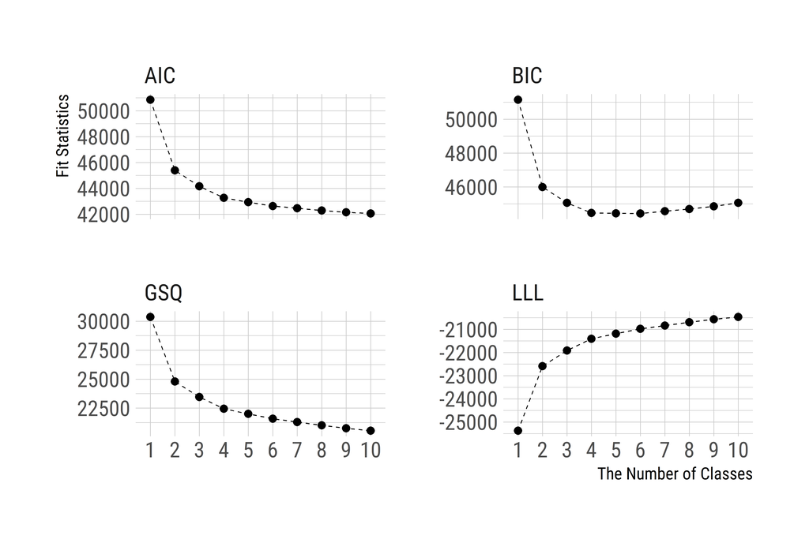

```r
# collect fit statistics
lca.fits.fitstats <-
  as.data.frame(matrix(NA, nrow = 10, ncol = 5))

for (loopfr in 1:10) {
  model <- lca.fits.baseline[[loopfr]]
  lca.fits.fitstats[loopfr, 1] <- loopfr
  lca.fits.fitstats[loopfr, 2] <- model$bic # BIC
  lca.fits.fitstats[loopfr, 3] <- model$aic # AIC
  lca.fits.fitstats[loopfr, 4] <- model$llik # Log-Likelihood
  lca.fits.fitstats[loopfr, 5] <- model$Gsq # Likelihood / Deviance
}
rm(model, loopfr) # clean-up

# pretty names
lca.fits.fitstats <- lca.fits.fitstats |>
  rename(N = V1,
         BIC = V2,
         AIC = V3,
         LLL = V4,
         GSQ = V5)

# plot the resultant statistics
lca.fits.fitstats |>
  pivot_longer(cols = !N, names_to = "Statistics", values_to = "Values") |>
  ggplot(aes(x = factor(N),
             y = Values)) +
  geom_point() +
  geom_line(size = .25, group = 1, linetype = "dashed") +
  labs(x = "The Number of Classes",
       y = "Fit Statistics") +
  theme_ipsum_rc() +
  facet_wrap(~ Statistics, nrow = 2, scales = "free_y")
```

The BIC clearly elbows at N = 4, which is in line with the previous literature. Let’s do the same analyses with `glca`. This package will allow us to calculate $G^2$ statistics along with bootstrap tests to validate whether N = 4 is the right choice.

## 1.2 Successive LCA Models Using `gLCA` Package

```r
lca.fits.validate <- list()
set.seed(11235)
for (loopfr in 2:10) {
  glcafits <- glca(
    item(
      natident1,
      natident2,
      natpride1,
      natpride2,
      natmembr1,
      natmembr2,
      natmembr3,
      natmembr4,
      nathubrs1,
      nathubrs2,
      nathubrs3,
      nathubrs4,
      natcultr1,
      natcultr2
    ) ~ 1,
    nclass = loopfr,
    n.init = 30,
    maxiter = 5000,
    data = df,
    verbose = F
  )
  lca.fits.validate[[loopfr]] <- glcafits
}
rm(loopfr, glcafits) # clean-up
```

### 1.2.1 Fit Statistics

```r
set.seed(11235)
lca.fits.validfit <- gofglca(
  lca.fits.validate[[2]],
  lca.fits.validate[[3]],
  lca.fits.validate[[4]],
  lca.fits.validate[[5]],
  lca.fits.validate[[6]],
  lca.fits.validate[[7]],
  lca.fits.validate[[8]],
  lca.fits.validate[[9]],
  lca.fits.validate[[10]], test = "boot")

lca.fits.validfit$gtable
```

```
##      logLik      AIC     CAIC      BIC   entropy Res.Df      Gsq Boot p-value
## 1 -22585.84 45397.67 46107.63 45994.63 0.9199430   1341 24801.86         0.04
## 2 -21912.99 44165.99 45234.06 45064.06 0.9118314   1284 23456.17         0.00
## 3 -21408.55 43271.10 44697.29 44470.29 0.8868623   1227 22447.28         0.10
## 4 -21186.53 42941.06 44725.36 44441.36 0.8980503   1170 22003.24         0.14
## 5 -20973.48 42628.96 44771.38 44430.38 0.8737609   1113 21577.14         0.10
## 6 -20841.07 42478.14 44978.68 44580.68 0.8830856   1056 21312.32         0.02
## 7 -20700.85 42311.70 45170.35 44715.35 0.8839215    999 21031.88         0.02
## 8 -20596.14 42216.29 45433.06 44921.06 0.8856883    942 20822.47         0.02
## 9 -20475.10 42088.20 45663.09 45094.09 0.8869106    885 20580.38         0.00
```

Cool! It seems that going from the 4-class model to a 5-class model does not provide that much of an additional information.

## 1.3 Model with 4 Classes

OK, we can now fit the model with N = 4 and several covariates. Some of the covariates (particularly `party` and `relig`) have sparse cells in the four-class solution, so we merge some of the categorical cells to achieve model convergence.

```r
# some brushes
df <- df |>
  mutate(
    party.bags = recode(
      party,
      "none" = "none",
      "cumhur" = "cumhur",
      "millet" = "millet",
      "emek" = "other",
      "other" = "other"
    ),
    relig.bags = ifelse(relig == "muslim", 0, 1)
  )

# model fit
set.seed(11234)
lca.data.4classes <- poLCA(
  cbind(
    natident1,
    natident2,
    natpride1,
    natpride2,
    natmembr1,
    natmembr2,
    natmembr3,
    natmembr4,
    nathubrs1,
    nathubrs2,
    nathubrs3,
    nathubrs4,
    natcultr1,
    natcultr2
  ) ~
    gender + age + ethnic + educ + relig.bags + religiosity + lifestyle +
    party.bags + ideology + polint + polinfo,
  nclass = 4,
  probs.start = lca.fits.baseline[[4]]$probs.start,
  nrep = 1,
  maxiter = 5000,
  data = df,
  verbose = F
)

# no need for old brushes
df <- df |> dplyr::select(-c(relig.bags, party.bags))
```

# 2 Latent Class Model Metrics

## 2.1 Visualizing Classes

Let’s visualize the composition of response patterns across four classes. Depending on the seed used, the ordering of the classes might change (see the seed used in the Latent Class fits above for the full replication of the following code).

```r
## visualize the item-response probabilities

broom::tidy(lca.data.4classes) |>
  group_by(variable, class) |>
  mutate(class = factor(
    class,
    levels = c(4, 2, 1, 3),
    labels = c("Ardent",
               "Creedal",
               "Disengaged",
               "Moderate")
  )) |>
  mutate(
    group = ifelse(
      variable %in% c("natident1",
                      "natident2"),
      "Identification",
      ifelse(
        variable %in% c("natpride1",
                        "natpride2"),
        "Pride",
        ifelse(
          variable %in% c("natcultr1",
                          "natcultr2"),
          "Culture",
          ifelse(
            variable %in% c(
              "natmembr1",
              "natmembr2",
              "natmembr3",
              "natmembr4"
            ),
            "Membership Criteria",
            "Hubris"
          )
        )
      )
    )) |>
      mutate(group = factor(
        group,
        levels = c(
          "Identification",
          "Pride",
          "Membership Criteria",
          "Hubris",
          "Culture"
        )
      )) |>
      ggplot(aes(
        x = variable,
        y = estimate,
        fill = factor(
          outcome,
          levels = c("1", "2", "3", "4", "5"),
          labels = c(
            "Strongly Disagree",
            "Disagree",
            "Neither Agree Nor Disagree",
            "Agree",
            "Strongly Agree"
          )
        )
      )) +
      geom_bar(
        stat = "identity",
        position = "stack",
        color = "black"
      ) +
      facet_grid(class ~ group, scale = "free_x", space = "free") +
      theme_ipsum_rc(grid = F) +
      theme(axis.text.x = element_text(angle = 45, hjust = 0.75)) +
      theme(legend.position = "right") +
      labs(x = "Variables", y = "Estimated Item Values", fill = "Response") +
      scale_fill_brewer(type = "seq", palette = "RdBu")
```

[figure not shown]

## 2.2 Group Differences

In what follows, we present the differences among nationalist classes in terms of several demographics.

```r
df <- df |>
  mutate(class = lca.data.4classes$predclass) |>
  mutate(class = factor(
    class,
    levels = c(4, 2, 1, 3),
    labels = c("Ardent",
               "Creedal",
               "Disengaged",
               "Moderate")
  ))

vtable::sumtable(
  df,
  vars = c(
    "gender",
    "age",
    "ethnic",
    "educ",
    "relig",
    "religiosity",
    "lifestyle",
    "party",
    "ideology",
    "polint",
    "polinfo"
  ),
  group = "class",
  group.test = T,
  digits = 2
)
```

Summary Statistics

| class Variable | Ardent N | Ardent Mean | Ardent SD | Creedal N | Creedal Mean | Creedal SD | Disengaged N | Disengaged Mean | Disengaged SD | Moderate N | Moderate Mean | Moderate SD | Test |
| --- | --- | --- | --- | --- | --- | --- | --- | --- | --- | --- | --- | --- | --- |
| gender | 463 |  |  | 511 |  |  | 182 |  |  | 299 |  |  | X2=2.314 |
| … male | 229 | 49% |  | 242 | 47% |  | 95 | 52% |  | 156 | 52% |  |  |
| … female | 234 | 51% |  | 269 | 53% |  | 87 | 48% |  | 143 | 48% |  |  |
| age | 463 | 0.39 | 0.26 | 511 | 0.38 | 0.25 | 182 | 0.42 | 0.28 | 299 | 0.42 | 0.27 | F=1.904 |
| ethnic | 463 |  |  | 511 |  |  | 182 |  |  | 299 |  |  | X2=313.046*** |
| … turk | 425 | 92% |  | 473 | 93% |  | 85 | 47% |  | 261 | 87% |  |  |
| … kurd | 25 | 5% |  | 7 | 1% |  | 77 | 42% |  | 25 | 8% |  |  |
| … other | 13 | 3% |  | 31 | 6% |  | 20 | 11% |  | 13 | 4% |  |  |
| educ | 463 | 0.5 | 0.27 | 511 | 0.55 | 0.28 | 182 | 0.57 | 0.28 | 299 | 0.56 | 0.27 | F=4.44*** |
| relig | 463 |  |  | 511 |  |  | 182 |  |  | 299 |  |  | X2=98.204*** |
| … muslim | 432 | 93% |  | 459 | 90% |  | 130 | 71% |  | 243 | 81% |  |  |
| … alevi | 31 | 7% |  | 44 | 9% |  | 30 | 16% |  | 43 | 14% |  |  |
| … other | 0 | 0% |  | 8 | 2% |  | 22 | 12% |  | 13 | 4% |  |  |
| religiosity | 463 | 0.73 | 0.23 | 511 | 0.66 | 0.22 | 182 | 0.55 | 0.32 | 299 | 0.59 | 0.27 | F=33.666*** |
| lifestyle | 463 | 0.58 | 0.33 | 511 | 0.63 | 0.26 | 182 | 0.65 | 0.31 | 299 | 0.67 | 0.21 | F=7.403*** |
| party | 463 |  |  | 511 |  |  | 182 |  |  | 299 |  |  | X2=681.317*** |
| … cumhur | 232 | 50% |  | 151 | 30% |  | 11 | 6% |  | 53 | 18% |  |  |
| … millet | 108 | 23% |  | 181 | 35% |  | 57 | 31% |  | 133 | 44% |  |  |
| … emek | 3 | 1% |  | 3 | 1% |  | 92 | 51% |  | 12 | 4% |  |  |
| … other | 21 | 5% |  | 26 | 5% |  | 6 | 3% |  | 26 | 9% |  |  |
| … none | 99 | 21% |  | 150 | 29% |  | 16 | 9% |  | 75 | 25% |  |  |
| ideology | 463 | 0.64 | 0.25 | 511 | 0.55 | 0.23 | 182 | 0.32 | 0.24 | 299 | 0.48 | 0.21 | F=89.777*** |
| polint | 463 | 0.65 | 0.29 | 511 | 0.61 | 0.28 | 182 | 0.64 | 0.29 | 299 | 0.59 | 0.29 | F=3.105** |
| polinfo | 463 | 0.46 | 0.27 | 511 | 0.47 | 0.25 | 182 | 0.42 | 0.27 | 299 | 0.49 | 0.27 | F=2.618** |

Statistical significance markers: * p<0.1; ** p<0.05; *** p<0.01

```r
save(df, file = "survey_dataframe_version3.R")
```

Proceed with the Step 3: Allocation Tasks.